# mtcars_linreg

Dennis Achterberg

2025-07-24

## Predicting fuel usage of a car using Linear Regression on mtcars dataset

We’ll explore R Markdown and stepwise linear regression in this notebook, using the mtcars dataset that’s already available in base R.

```r
#load the data
data(mtcars)

#get a first idea of the data
head(mtcars)
```

```
##                    mpg cyl disp  hp drat    wt  qsec vs am gear carb
## Mazda RX4         21.0   6  160 110 3.90 2.620 16.46  0  1    4    4
## Mazda RX4 Wag     21.0   6  160 110 3.90 2.875 17.02  0  1    4    4
## Datsun 710        22.8   4  108  93 3.85 2.320 18.61  1  1    4    1
## Hornet 4 Drive    21.4   6  258 110 3.08 3.215 19.44  1  0    3    1
## Hornet Sportabout 18.7   8  360 175 3.15 3.440 17.02  0  0    3    2
## Valiant           18.1   6  225 105 2.76 3.460 20.22  1  0    3    1
```

The mtcars dataset has been loaded, and head() provides a glimpse into its structure.

```r
#get the summary
summary(mtcars)
```

```
##       mpg             cyl             disp             hp
##  Min.   :10.40   Min.   :4.000   Min.   : 71.1   Min.   : 52.0
##  1st Qu.:15.43   1st Qu.:4.000   1st Qu.:120.8   1st Qu.: 96.5
##  Median :19.20   Median :6.000   Median :196.3   Median :123.0
##  Mean   :20.09   Mean   :6.188   Mean   :230.7   Mean   :146.7
##  3rd Qu.:22.80   3rd Qu.:8.000   3rd Qu.:326.0   3rd Qu.:180.0
##  Max.   :33.90   Max.   :8.000   Max.   :472.0   Max.   :335.0
##       drat             wt             qsec             vs
##  Min.   :2.760   Min.   :1.513   Min.   :14.50   Min.   :0.0000
##  1st Qu.:3.080   1st Qu.:2.581   1st Qu.:16.89   1st Qu.:0.0000
##  Median :3.695   Median :3.325   Median :17.71   Median :0.0000
##  Mean   :3.597   Mean   :3.217   Mean   :17.85   Mean   :0.4375
##  3rd Qu.:3.920   3rd Qu.:3.610   3rd Qu.:18.90   3rd Qu.:1.0000
##  Max.   :4.930   Max.   :5.424   Max.   :22.90   Max.   :1.0000
##        am              gear            carb
##  Min.   :0.0000   Min.   :3.000   Min.   :1.000
##  1st Qu.:0.0000   1st Qu.:3.000   1st Qu.:2.000
##  Median :0.0000   Median :4.000   Median :2.000
##  Mean   :0.4062   Mean   :3.688   Mean   :2.812
##  3rd Qu.:1.0000   3rd Qu.:4.000   3rd Qu.:4.000
##  Max.   :1.0000   Max.   :5.000   Max.   :8.000
```

Now we know what variables are contained in the Dataset and how they are  
distributed. Some information on the variables:

| Column | Description |
| --- | --- |
| mpg | Miles/(US) gallon |
| cyl | Number of cylinders |
| disp | Displacement (cu.in.) |
| hp | Gross horsepower |
| drat | Rear axle ratio |
| wt | Weight (1000 lbs) |
| qsec | 1/4 mile time |
| vs | Engine (0 = V-shaped, 1 = straight) |
| am | Transmission (0 = automatic, 1 = manual) |
| gear | Number of forward gears |
| carb | Number of carburetors |

Source: [www.rdocumentation.org](https://www.rdocumentation.org/packages/datasets/versions/3.6.2/topics/mtcars)

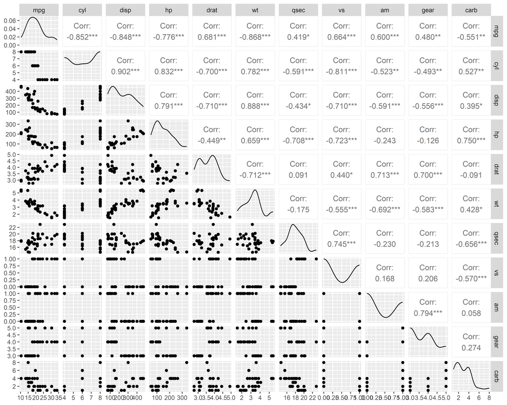

The ggpairs plot allows for a visual inspection of pairwise relationships between variables. While not all pairs exhibit perfect linearity, the relationships between mpg and several predictor variables (e.g., wt, cyl, hp) appear sufficiently linear to proceed with a linear regression analysis.

We are going to implement a stepwise model search, choosing to add variables based on AIC  
until we have found the optimal model. Starting with the “zero model” and adding variables  
we are essentially doing forward search, with the added option of also removing a variable  
therefore it is bi-directional.

```r
# Define the null model (starting point with only an intercept)
# This model says mpg is explained by nothing but a constant.
lmod0 <- lm(mpg ~ 1, data = mtcars)
stepmodb <- step(lmod0,
                 direction = "both",
                 scope=.~.+cyl + disp + hp + drat + wt + qsec + vs + am + gear + carb)
```

```
## Start:  AIC=115.94
## mpg ~ 1
##
##        Df Sum of Sq     RSS     AIC
## + wt    1    847.73  278.32  73.217
## + cyl   1    817.71  308.33  76.494
## + disp  1    808.89  317.16  77.397
## + hp    1    678.37  447.67  88.427
## + drat  1    522.48  603.57  97.988
## + vs    1    496.53  629.52  99.335
## + am    1    405.15  720.90 103.672
## + carb  1    341.78  784.27 106.369
## + gear  1    259.75  866.30 109.552
## + qsec  1    197.39  928.66 111.776
## <none>              1126.05 115.943
##
## Step:  AIC=73.22
## mpg ~ wt
##
##        Df Sum of Sq     RSS     AIC
## + cyl   1     87.15  191.17  63.198
## + hp    1     83.27  195.05  63.840
## + qsec  1     82.86  195.46  63.908
## + vs    1     54.23  224.09  68.283
## + carb  1     44.60  233.72  69.628
## + disp  1     31.64  246.68  71.356
## <none>               278.32  73.217
## + drat  1      9.08  269.24  74.156
## + gear  1      1.14  277.19  75.086
## + am    1      0.00  278.32  75.217
## - wt    1    847.73 1126.05 115.943
##
## Step:  AIC=63.2
## mpg ~ wt + cyl
##
##        Df Sum of Sq    RSS    AIC
## + hp    1    14.551 176.62 62.665
## + carb  1    13.772 177.40 62.805
## <none>              191.17 63.198
## + qsec  1    10.567 180.60 63.378
```

[output cut: 8 more lines]

```
## Step:  AIC=62.66
## mpg ~ wt + cyl + hp
##
##        Df Sum of Sq    RSS    AIC
## <none>              176.62 62.665
## - hp    1    14.551 191.17 63.198
## + am    1     6.623 170.00 63.442
## + disp  1     6.176 170.44 63.526
## - cyl   1    18.427 195.05 63.840
## + carb  1     2.519 174.10 64.205
## + drat  1     2.245 174.38 64.255
## + qsec  1     1.401 175.22 64.410
## + gear  1     0.856 175.76 64.509
## + vs    1     0.060 176.56 64.654
## - wt    1   115.354 291.98 76.750
```

The stepwise search in both directions gave us the model mpg ~ wt + cyl + hp with AIC 62.66.  
To mitigate the risk of converging to a local optimum, a backward stepwise selection will also be performed. This approach begins with a full model (including all potential predictors) and iteratively removes variables based on AIC until the optimal model is identified.  
We are going to start with all variables and then remove them based on AIC until we arrive  
at the optimal model.

```r
#starting point here is a linear model that contains all variables
lmodall <- lm(mpg ~ cyl + disp + hp + drat + wt + qsec + vs + am + gear + carb, data =mtcars)


stepmod_backw <- step(lmodall, direction = "backward")
```

```
## Start:  AIC=70.9
## mpg ~ cyl + disp + hp + drat + wt + qsec + vs + am + gear + carb
##
##        Df Sum of Sq    RSS    AIC
## - cyl   1    0.0799 147.57 68.915
## - vs    1    0.1601 147.66 68.932
## - carb  1    0.4067 147.90 68.986
## - gear  1    1.3531 148.85 69.190
## - drat  1    1.6270 149.12 69.249
## - disp  1    3.9167 151.41 69.736
## - hp    1    6.8399 154.33 70.348
## - qsec  1    8.8641 156.36 70.765
## <none>              147.49 70.898
## - am    1   10.5467 158.04 71.108
## - wt    1   27.0144 174.51 74.280
##
## Step:  AIC=68.92
## mpg ~ disp + hp + drat + wt + qsec + vs + am + gear + carb
##
##        Df Sum of Sq    RSS    AIC
## - vs    1    0.2685 147.84 66.973
## - carb  1    0.5201 148.09 67.028
## - gear  1    1.8211 149.40 67.308
## - drat  1    1.9826 149.56 67.342
## - disp  1    3.9009 151.47 67.750
## - hp    1    7.3632 154.94 68.473
## <none>              147.57 68.915
## - qsec  1   10.0933 157.67 69.032
## - am    1   11.8359 159.41 69.384
## - wt    1   27.0280 174.60 72.297
##
## Step:  AIC=66.97
## mpg ~ disp + hp + drat + wt + qsec + am + gear + carb
##
##        Df Sum of Sq    RSS    AIC
## - carb  1    0.6855 148.53 65.121
## - gear  1    2.1437 149.99 65.434
## - drat  1    2.2139 150.06 65.449
## - disp  1    3.6467 151.49 65.753
## - hp    1    7.1060 154.95 66.475
```

[output cut: 44 more lines]

```
##        Df Sum of Sq    RSS    AIC
## - hp    1     9.219 169.29 61.307
## <none>              160.07 61.515
## - qsec  1    20.225 180.29 63.323
## - am    1    25.993 186.06 64.331
## - wt    1    78.494 238.56 72.284
##
## Step:  AIC=61.31
## mpg ~ wt + qsec + am
##
##        Df Sum of Sq    RSS    AIC
## <none>              169.29 61.307
## - am    1    26.178 195.46 63.908
## - qsec  1   109.034 278.32 75.217
## - wt    1   183.347 352.63 82.790
```

The backwards search gave us the model mpg ~ wt + qsec + am with an AIC of 61.31 This is better than the previous model, as we want to reduce AIC.  
Semantically we are using the weight,  
acceleration and transmission type to predict the gas usage, which makes sense.

### Residual analysis

As linear regression is based upon several assumptions, we are going to check if  
our data falls in line with these. An important aspect of that are the residuals.

Residuals are the “prediction errors” between the actual value y and the predicted  
value ^y, subtracting the ^y from y gives us the residual.

In regard to the CRISP-DM Framework this step can be considered “evaluation”

##### Residual Plot:

Plotting standardized residuals against predicted values helps assess the assumptions of linearity and homoscedasticity. Ideally, we want to see a random scatter of points around the horizontal line at zero, with no discernible patterns or fanning (indicating constant variance).

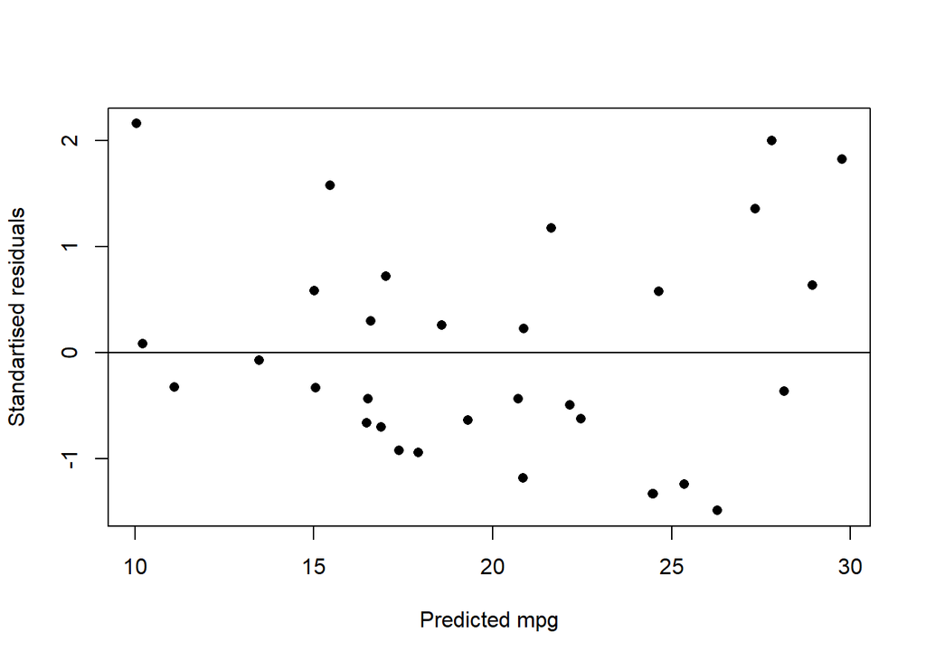

```r
predicted <- fitted (stepmod_backw)
st_res <- rstandard(stepmod_backw)

#the plot itself:
plot (predicted, st_res,pch=16,
      xlab = "Predicted mpg",
      ylab = "Standartised residuals")
abline(h=0)
```

While some minor deviations are present, the residuals appear to be relatively evenly scattered around zero, suggesting that the linearity assumption is largely met and there are no severe signs of heteroscedasticity.

##### QQ-Plot

A Quantile-Quantile (Q-Q) plot is used to assess the normality of the standardized residuals. It plots the quantiles of the observed residuals against the theoretical quantiles of a standard normal distribution (a straight line)

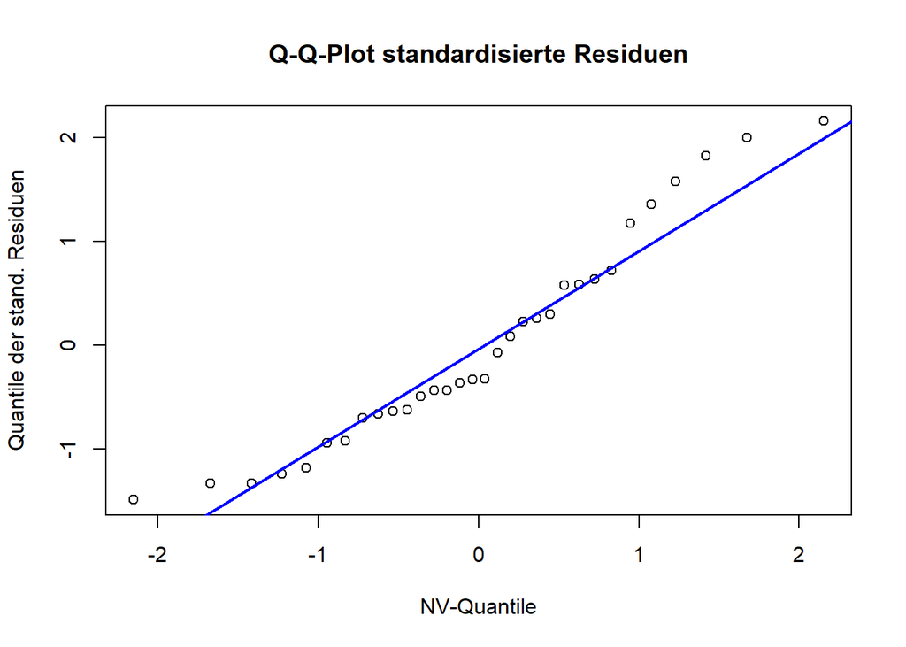

```r
qqnorm(st_res,
       xlab="NV-Quantile",
       ylab="Quantile der stand. Residuen",
       main="Q-Q-Plot standardisierte Residuen")

# Referenzgerade für Normalverteilung
qqline(st_res, col="blue", lwd=2)
```

The points generally follow the blue reference line, indicating that the residuals are approximately normally distributed. There might be slight deviations at the tails, which is common with smaller datasets, but overall, it suggests the normality assumption is reasonably satisfied.

```r
shapiro.test(st_res)
```

```
##
##  Shapiro-Wilk normality test
##
## data:  st_res
## W = 0.94225, p-value = 0.08674
```

Shapiro wilk assumes the H_0 of residuals being normally distributed, with H_1 being the opposite. Therefore contrary to most other tests, we generally want to keep H_0 so high o values are good.

At a significance level (alpha) of 0.05, the p-value from the Shapiro-Wilk test is 0.08674. Since this p-value is greater than 0.05, we fail to reject the null hypothesis. This indicates that there is no significant evidence to suggest that the residuals deviate from a normal distribution, thus supporting the normality assumption for our linear regression model.